# edgeR analysis of A673 data

This document details comparisons between the time points in the A673 data to extract differential expression information.

## Setting up the environment

These are packages you will need for this notebook. For exact versions used, please refer to the session info at the bottom of this notebook.

```r
##########################################################################################
library('tidyverse')
library('ggplot2')
library('RColorBrewer')
library('limma')
library('edgeR')
library('ggrepel')
```

I want to set a base directory that we can use as a link to the directory where we will do most of the work. I use two directories here because the Workspace is what is pushed to GitHub and contains scripts and plot files, but the Repository is where more of the big data is stored that does not get pushed.

```r
##########################################################################################
generalDatasets = 'C:/Users/chughes/Documents/bccrc/projectsRepository/generalDatasets'
baseWorkspace = 'C:/Users/chughes/Documents/bccrc/projectsWorkspace/sorensenLab/relatedToDlg2'
baseRepository = 'C:/Users/chughes/Documents/bccrc/projectsRepository/sorensenLab/relatedToDlg2'
#generalDatasets = 'C:/Users/chris/OneDrive/Documents/bccrc/projectsRepository/generalDatasets'
#baseWorkspace = 'C:/Users/chris/OneDrive/Documents/bccrc/projectsWorkspace/sorensenLab/relatedToYbx1'
#baseRepository = 'C:/Users/chris/OneDrive/Documents/bccrc/projectsRepository/sorensenLab/relatedToYbx1'
```

## Data processing

Read in the normalized data.

```r
##########################################################################################
dataIrsRaw = as.data.frame(readRDS(paste(baseRepository, '/proteomics20201223_a673ShEwsFli1DoxTimecourseSetA/dataset_proteinSetABCIrsNormalized.rds', sep = '')))
row.names(dataIrsRaw) = dataIrsRaw$accession
dataIrsRaw = dataIrsRaw[complete.cases(dataIrsRaw),]
dataIrs = dataIrsRaw[,c(2,10,18,3,11,19)] #I only keep the two time points I want to compare here
```

```r
# we will skip applying TMM normalization (using the calcNormFactors function)
# we need to estimate the dispersion terms (global and local)
test = estimateCommonDisp(yIrs, verbose=T)
```

```
Disp = 0.00978 , BCV = 0.0989
```

Check what this looks like from a differential expression standpoint.

```r
##########################################################################################
# the exact test object has columns like fold-change, CPM, and p-values
groupOfInterestA = 'day7'
groupOfInterestB = 'day0'
etIrs = exactTest(yIrs, pair = c(groupOfInterestA, groupOfInterestB))

# this counts up, down, and unchanged genes
summary(decideTestsDGE(etIrs))
```

[output not shown]

This looks mostly as expected, a lot of significant genes. Assign some FDR values and look at the overall results.

```r
##########################################################################################
# the topTags function adds the BH FDR values to an exactTest data frame. Make sure we do not change the row order!
ttIrs = topTags(etIrs, n = Inf, sort.by = "none")
ttIrs = ttIrs$table #We just need the data frame table

# add the default value as a new column
ttIrs$candidate = "no"
ttIrs[which(ttIrs$FDR <= 0.10 & ttIrs$FDR > 0.05), dim(ttIrs)[2]] = "low"
ttIrs[which(ttIrs$FDR <= 0.05 & ttIrs$FDR > 0.01), dim(ttIrs)[2]] = "med"
ttIrs[which(ttIrs$FDR <= 0.01), dim(ttIrs)[2]] = "high"
ttIrs$candidate = factor(ttIrs$candidate, levels = c("high", "med", "low", "no"))

# what does ttIrs look like?
head(ttIrs)
```

|  | logFC | logCPM | PValue | FDR | candidate |
| --- | --- | --- | --- | --- | --- |
| A0A024R1R8 | 0.3070963 | 4.2416976 | 1.315571e-06 | 2.384938e-06 | high |
| A0A024RBG1 | 1.3991835 | 5.2718509 | 1.268531e-122 | 3.254906e-121 | high |
| A0A075B759 | 0.2094253 | 1.5505471 | 6.738398e-02 | 8.306071e-02 | low |
| A0A087WUL8 | 0.8275672 | 0.1608155 | 4.901536e-10 | 1.073541e-09 | high |
| A0A087WUV0 | 0.7392952 | 3.0793181 | 8.694536e-13 | 2.174910e-12 | high |
| A0A096LP55 | 0.6713022 | 1.9615456 | 5.789881e-11 | 1.328348e-10 | high |

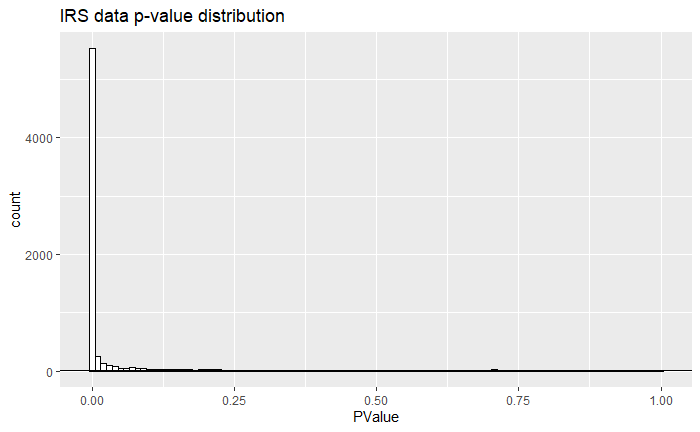

```r
# what does the test p-value distribution look like?
ggplot(ttIrs, aes(PValue)) +
  geom_histogram(bins = 100, fill = "white", color = "black") +
  geom_hline(yintercept = mean(hist(ttIrs$PValue, breaks = 100, plot = FALSE)$counts[26:100])) +
  ggtitle("IRS data p-value distribution")
```

Make some plots of the results.

```r
##########################################################################################
samplesA = c(which(grepl(groupOfInterestA, colnames(dataIrs))))
samplesB = c(which(grepl(groupOfInterestB, colnames(dataIrs))))
deIrs = data.frame(rowMeans(dataIrs[samplesA]), rowMeans(dataIrs[samplesB]), ttIrs$candidate)
colnames(deIrs) = c('samplesA','samplesB', 'candidate')
head(deIrs)
```

|  | samplesA | samplesB | candidate |
| --- | --- | --- | --- |
| A0A024R1R8 | 2432303.7 | 3005592.5 | high |
| A0A024RBG1 | 3051454.1 | 8052946.4 | high |
| A0A075B759 | 391339.6 | 451603.3 | low |
| A0A087WUL8 | 115783.7 | 205048.1 | high |
| A0A087WUV0 | 912074.4 | 1520757.8 | high |
| A0A096LP55 | 432087.5 | 687496.1 | high |

```r
# we need the transformed data for the volcano plot
volcanoIrs = data.frame(-1*ttIrs$logFC, -1*log10(ttIrs$FDR), ttIrs$candidate)
colnames(volcanoIrs) = c("FoldChange", "FDR", "candidate")
head(volcanoIrs)
```

|  | FoldChange | FDR | candidate |
| --- | --- | --- | --- |
| 1 | -0.3070963 | 5.622523 | high |
| 2 | -1.3991835 | 120.487462 | high |
| 3 | -0.2094253 | 1.080604 | low |
| 4 | -0.8275672 | 8.969182 | high |
| 5 | -0.7392952 | 11.662559 | high |
| 6 | -0.6713022 | 9.876688 | high |

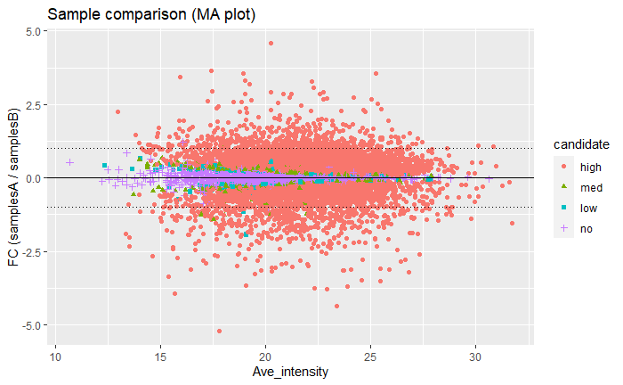

```r
# start with MA plot
temp = data.frame(log2((deIrs$samplesA + deIrs$samplesB)/2), log2(deIrs$samplesB/deIrs$samplesA), deIrs$candidate)
colnames(temp) = c("Ave", "FC", "candidate")
ggplot(temp, aes(x = Ave, y = FC)) +
  geom_point(aes(color = candidate, shape = candidate)) +
  scale_y_continuous("FC (samplesA / samplesB)") +
  scale_x_continuous("Ave_intensity") +
  ggtitle("Sample comparison (MA plot)") +
  geom_hline(yintercept = 0.0, color = "black") + # one-to-one line
  geom_hline(yintercept = 1.0, color = "black", linetype = "dotted") + # 2-fold up
  geom_hline(yintercept = -1.0, color = "black", linetype = "dotted") # 2-fold down
```

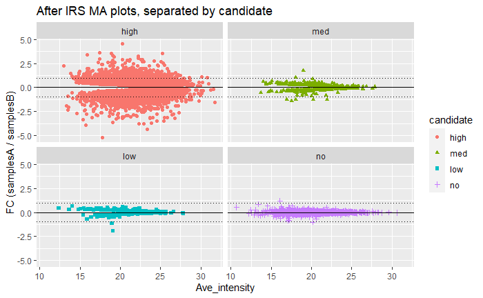

```r
# make separate MA plots
ggplot(temp, aes(x = Ave, y = FC)) +
  geom_point(aes(color = candidate, shape = candidate)) +
  scale_y_continuous("FC (samplesA / samplesB)") +
  scale_x_continuous("Ave_intensity") +
  geom_hline(yintercept = 0.0, color = "black") + # one-to-one line
  geom_hline(yintercept = 1.0, color = "black", linetype = "dotted") + # 2-fold up
  geom_hline(yintercept = -1.0, color = "black", linetype = "dotted") + # 2-fold down
  facet_wrap(~ candidate) +
  ggtitle("After IRS MA plots, separated by candidate")
```

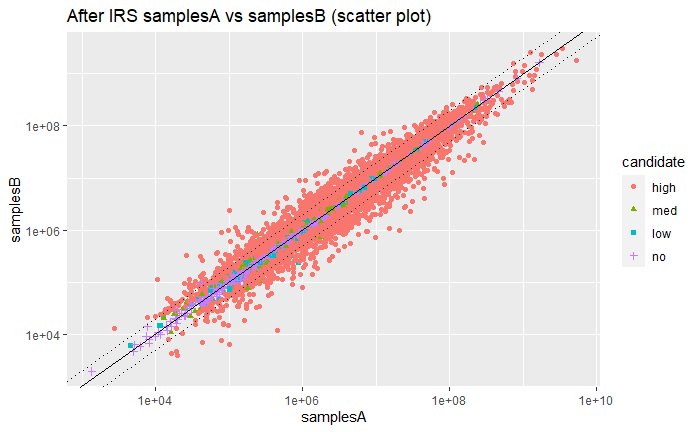

```r
# make the combined candidate corelation plot
ggplot(deIrs, aes(x = samplesA, y = samplesB)) +
  geom_point(aes(color = candidate, shape = candidate)) +
  scale_y_log10() +
  scale_x_log10() +
  ggtitle("After IRS samplesA vs samplesB (scatter plot)") +
  geom_abline(intercept = 0.0, slope = 1.0, color = "black") + # one-to-one line
  geom_abline(intercept = 0.301, slope = 1.0, color = "black", linetype = "dotted") + # 2-fold up
  geom_abline(intercept = -0.301, slope = 1.0, color = "black", linetype = "dotted") # 2-fold down
```

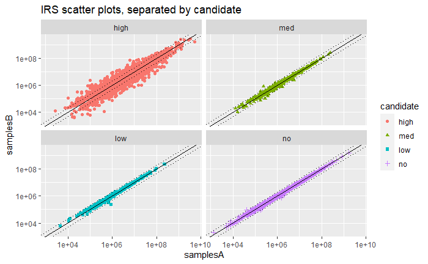

```r
# make separate corelation plots
ggplot(deIrs, aes(x = samplesA, y = samplesB)) +
  geom_point(aes(color = candidate, shape = candidate)) +
  scale_y_log10() +
  scale_x_log10() +
  geom_abline(intercept = 0.0, slope = 1.0, color = "black") + # one-to-one line
  geom_abline(intercept = 0.301, slope = 1.0, color = "black", linetype = "dotted") + # 2-fold up
  geom_abline(intercept = -0.301, slope = 1.0, color = "black", linetype = "dotted") + # 2-fold down
  facet_wrap(~ candidate) +
  ggtitle("IRS scatter plots, separated by candidate")
```

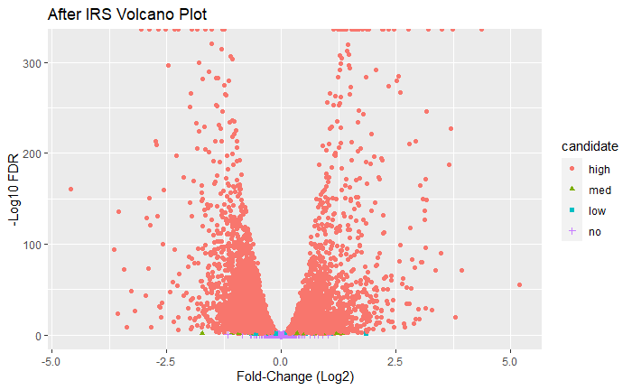

```r
# make a volcano plot
ggplot(volcanoIrs, aes(x = FoldChange, y = FDR)) +
  geom_point(aes(color = candidate, shape = candidate)) +
  xlab("Fold-Change (Log2)") +
  ylab("-Log10 FDR") +
  ggtitle("After IRS Volcano Plot")
```

Reassign some of he annotation.

```r
##########################################################################################
volcanoIrs$accession = dataIrsRaw$accession
volcanoIrs$gene = dataIrsRaw$gene
##
volcanoIrs[grepl('^IL1RAP$', volcanoIrs$gene),]
```

|  | FoldChange | FDR | candidate | accession | gene |
| --- | --- | --- | --- | --- | --- |
| 6519 | -2.284497 | 196.9553 | high | Q9NPH3 | IL1RAP |

```r
volcanoIrs[grepl('^DLG2$', volcanoIrs$gene),]
```

|  | FoldChange | FDR | candidate | accession | gene |
| --- | --- | --- | --- | --- | --- |
| 3366 | -3.06198 | Inf | high | Q15700 | DLG2 |

```r
##save the data
write.table(volcanoIrs,
            paste(baseRepository, '/proteomics20201223_a673ShEwsFli1DoxTimecourseSetA/dataset_edgerIrs_',groupOfInterestA,'-',groupOfInterestB,'.csv', sep = ''),
            sep = ',', row.names = FALSE, quote = FALSE)
```

[figure not shown]

This is giving me quite a few Inf values for FDR, I guess because they are so significant. The dataset appears to have relatively low variability (possibly due to the strength of the IRS normalization). I want to try deqMS and see how it does.

[session information not shown]